# ZERO-INFLATED POISSON REGRESSION

Equipo: Carlos Andrés Cuartas Murillo - cacuartasm@eafit.edu.co / Carlos Alberto Cerro Espinal - cacuartasm@eafit.edu.co / Daniel Román Ramírez - dromanr@eafit.edu.co / Daniel Enrique Pinto Restrepo - dpintor1@eafit.edu.co / Santiago Mejía Chitiva - smejiac3@eafit.edu.co

5/16/2020

```r
Sys.setlocale("LC_TIME","Spanish")
```

```
## [1] "Spanish_Spain.1252"
```

```r
setwd("C:/Users/droma/Universidad EAFIT/Proyecto_integrador_2020-01 - General/4. Notebooks/R/Model_poisson_zero_inflated") ## Directorio de trabajo
```

### Contexto

La regresión de Poisson inflada a cero se utiliza para modelar datos de **conteo** que tienen un **exceso de conteos cero**. Además, la teoría sugiere que los ceros en exceso se generan mediante un **proceso separado de los valores de conteo y que los ceros en exceso se pueden modelar de forma independiente**. Por lo tanto, el modelo zip tiene dos partes, **un modelo de conteo de Poisson y el modelo logit para predecir el exceso de ceros**.

**https://stats.idre.ucla.edu/r/dae/zip/**

### Modelo Poisson para predicción de la demanda para empresa del sector retail

Se requiere analizar el efecto de variables transaccionales y de tiempo que tiene sobre la demanda para la compañia Walmart, el efecto de este estudio es poder tener la demanda necesaria para las temporadas durante el año de ventas. En este caso tenemos **un conteo en la variable respuesta demanda** se evidencia una gran existencia de zeros que indica los días que no se tuvo demanda.

## Modelo Poisson

La distribución de Poisson es una distribución de probabilidad discreta que expresa, a partir de una **frecuencia de ocurrencia** media, la probabilidad de que **ocurra un determinado número de eventos durante cierto período de tiempo**. Concretamente, se especializa en la probabilidad de ocurrencia de sucesos con probabilidades muy pequeñas, o sucesos «raros». “tomado de Siméon-Denis Poisson, trabajo Recherches sur la probabilité des jugements en matières criminelles et matière civile (Investigación sobre la probabilidad de los juicios en materias criminales y civiles).”

## Propiedades

A continuación se identifica la **función de densidad de probabilidad de Poisson**

$f(k,\lambda)= \frac{e^{-\lambda}\lambda ^{k}}{k!}$

- k es el número de ocurrencias del evento o fenómeno (la función nos da la probabilidad de que el evento suceda precisamente k veces).
- $\lambda$ es un parámetro positivo que representa el número de veces que se espera que ocurra el fenómeno durante un intervalo dado. Por ejemplo, si el suceso estudiado tiene lugar en promedio 4 veces por minuto y estamos interesados en la probabilidad de que ocurra k veces dentro de un intervalo de 10 minutos, usaremos un modelo de distribución de Poisson con $\lambda = 10×4 = 40.$
- $e$ es la base de los logaritmos naturales ($e = 2,71828…$)

# La función generadora de momentos con valor esperado $\lambda$ es:

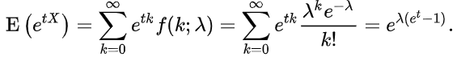

Las variables aleatorias de Poisson tienen la propiedad de ser infinitamente divisibles.

La divergencia Kullback-Leibler desde una variable aleatoria de Poisson de parámetro $\lambda_0$ a otra de parámetro $\lambda$ es

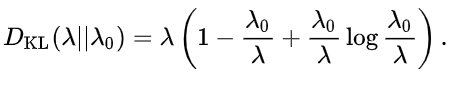

# Definición intervalos de confianza

Dada una serie de eventos k (al menos el 15-20) en un periodo de tiempo T, los límites del intervalo de confianza para la frecuencia vienen dadas por:

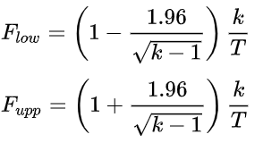

## Desarrollo

### Librerías

```r
#librarias para el desarrollo
library(readr)
library(dplyr)
library(plotly)
library(ggplot2)
library(corrplot)
library(lattice)
library(psych)
library(car)
library(stats)
library(FactoMineR)
library(readxl)
library(nortest)
library(tseries)
library(rafalib)
library(MASS)
library(caret)
library(leaps)
library(pscl)
# librerias para data manipulation
library('dplyr') # data manipulation
library('readr') # input/output
library('vroom') # input/output
library('skimr') # overview
library('tibble') # data wrangling
library('tidyr') # data wrangling
library('purrr') # data wrangling
library('stringr') # string manipulation
library('forcats') # factor manipulation
library(xtable) # generación de tablas
library(kableExtra)

# Date + forecast
library('lubridate') # date and time
library('forecast') # time series analysis
library('prophet') # time series analysis
library('timetk') # time series analysis

# Interactivity
library('crosstalk')
library('plotly')

# parallel
library('foreach')
library('doParallel')

library(feather)
library(data.table)
library(ggplot2)
library(plotly)
library(animation)

#poisson
require(ggplot2)
require(pscl)
require(boot)
library(sandwich)
library(msm)
library(arm)
library(jtools)
#library(broom)
library(ggstance)
library(Metrics)
```

### Carga de datos

Se implementará el modelo para una referencia y posteriormente se escalara para todas las referencias.

```r
dt1<-read.csv("food_1_001.csv", sep = ",")
```

### Nombres de las columnas de la base

los nombres de la base se guarda en un vector

```r
M <-names(dt1)
M
```

```
##  [1] "wm_yr_wk"                  "item_id"
##  [3] "d"                         "units"
##  [5] "ln_units"                  "date"
##  [7] "weekday"                   "wday"
##  [9] "month"                     "year"
## [11] "event_name_1"              "event_type_1"
## [13] "event_name_2"              "event_type_2"
## [15] "snap_CA"                   "snap_TX"
## [17] "snap_WI"                   "month_2"
## [19] "events"                    "weekday_Friday"
## [21] "weekday_Monday"            "weekday_Saturday"
## [23] "weekday_Sunday"            "weekday_Thursday"
## [25] "weekday_Tuesday"           "weekday_Wednesday"
## [27] "month_2_enero"             "month_2_febrero"
## [29] "month_2_marzo"             "month_2_abril"
```

[output cut: 22 more lines]

### Resumen del dataset

```r
dim(dt1) # dimensión de la base
```

```
## [1] 1913   73
```

```r
class(dt1) # clase del data set
```

```
## [1] "data.frame"
```

```r
s<-summary(dt1) # resumen de la base

s  %>%
  head(10) %>%
  kable() %>%
  kable_styling() %>%
  kableExtra::scroll_box(width = "100%")
```

|  | wm_yr_wk | item_id | d | units | ln_units | date | weekday | wday | month | year | event_name_1 | event_type_1 | event_name_2 | event_type_2 | snap_CA | snap_TX | snap_WI | month_2 | events | weekday_Friday | weekday_Monday | weekday_Saturday | weekday_Sunday | weekday_Thursday | weekday_Tuesday | weekday_Wednesday | month_2_enero | month_2_febrero | month_2_marzo | … |
| --- | --- | --- | --- | --- | --- | --- | --- | --- | --- | --- | --- | --- | --- | --- | --- | --- | --- | --- | --- | --- | --- | --- | --- | --- | --- | --- | --- | --- | --- | --- |
|  | Min. :11101 | FOODS_1_001:1913 | d_1 : 1 | Min. : 0.0000 | Min. :0.0000 | 1/1/2012 : 1 | Friday :273 | Min. :1.000 | Min. : 1.000 | Min. :2011 | :1759 | :1759 | :1909 | :1909 | Min. :0.0000 | Min. :0.0000 | Min. :0.0000 | marzo :186 | none :1759 | Min. :0.0000 | Min. :0.0000 | Min. :0.0000 | Min. :0.0000 | Min. :0.0000 | Min. :0.0000 | Min. :0.0000 | Min. :0.00000 | Min. :0.00000 | Min. :0.00000 | … |
|  | 1st Qu.:11217 | NA | d_10 : 1 | 1st Qu.: 0.0000 | 1st Qu.:0.0000 | 1/1/2013 : 1 | Monday :273 | 1st Qu.:2.000 | 1st Qu.: 3.000 | 1st Qu.:2012 | LentStart : 6 | Cultural : 35 | Cinco De Mayo : 1 | Cultural : 3 | 1st Qu.:0.0000 | 1st Qu.:0.0000 | 1st Qu.:0.0000 | abril :174 | lentstart : 6 | 1st Qu.:0.0000 | 1st Qu.:0.0000 | 1st Qu.:0.0000 | 1st Qu.:0.0000 | 1st Qu.:0.0000 | 1st Qu.:0.0000 | 1st Qu.:0.0000 | 1st Qu.:0.00000 | 1st Qu.:0.00000 | 1st Qu.:0.00000 | … |
|  | Median :11333 | NA | d_100 : 1 | Median : 0.0000 | Median :0.0000 | 1/1/2014 : 1 | Saturday :274 | Median :4.000 | Median : 6.000 | Median :2013 | LentWeek2 : 6 | National : 51 | Easter : 1 | Religious: 1 | Median :0.0000 | Median :0.0000 | Median :0.0000 | febrero :170 | lentweek2 : 6 | Median :0.0000 | Median :0.0000 | Median :0.0000 | Median :0.0000 | Median :0.0000 | Median :0.0000 | Median :0.0000 | Median :0.00000 | Median :0.00000 | Median :0.00000 | … |
|  | Mean :11339 | NA | d_1000 : 1 | Mean : 0.7857 | Mean :0.1833 | 1/1/2015 : 1 | Sunday :274 | Mean :3.997 | Mean : 6.358 | Mean :2013 | PresidentsDay: 6 | Religious: 52 | Father’s day : 1 | NA | Mean :0.3293 | Mean :0.3293 | Mean :0.3293 | enero :158 | presidentday : 6 | Mean :0.1427 | Mean :0.1427 | Mean :0.1432 | Mean :0.1432 | Mean :0.1427 | Mean :0.1427 | Mean :0.1427 | Mean :0.08259 | Mean :0.08887 | Mean :0.09723 | … |
|  | 3rd Qu.:11448 | NA | d_1001 : 1 | 3rd Qu.: 1.0000 | 3rd Qu.:0.0000 | 1/1/2016 : 1 | Thursday :273 | 3rd Qu.:6.000 | 3rd Qu.: 9.000 | 3rd Qu.:2015 | Purim End : 6 | Sporting : 16 | OrthodoxEaster: 1 | NA | 3rd Qu.:1.0000 | 3rd Qu.:1.0000 | 3rd Qu.:1.0000 | agosto :155 | purim_end : 6 | 3rd Qu.:0.0000 | 3rd Qu.:0.0000 | 3rd Qu.:0.0000 | 3rd Qu.:0.0000 | 3rd Qu.:0.0000 | 3rd Qu.:0.0000 | 3rd Qu.:0.0000 | 3rd Qu.:0.00000 | 3rd Qu.:0.00000 | 3rd Qu.:0.00000 | … |
|  | Max. :11613 | NA | d_1002 : 1 | Max. :15.0000 | Max. :2.7081 | 1/10/2012: 1 | Tuesday :273 | Max. :7.000 | Max. :12.000 | Max. :2016 | StPatricksDay: 6 | NA | NA | NA | Max. :1.0000 | Max. :1.0000 | Max. :1.0000 | diciembre:155 | stpatricksday: 6 | Max. :1.0000 | Max. :1.0000 | Max. :1.0000 | Max. :1.0000 | Max. :1.0000 | Max. :1.0000 | Max. :1.0000 | Max. :1.00000 | Max. :1.00000 | Max. :1.00000 | … |
|  | NA | NA | (Other):1907 | NA | NA | (Other) :1907 | Wednesday:273 | NA | NA | NA | (Other) : 124 | NA | NA | NA | NA | NA | NA | (Other) :915 | (Other) : 124 | NA | NA | NA | NA | NA | NA | NA | NA | NA | NA | … |

## Comportamiento de la variable respuesta

En esta gráfica se observa el comportamiento de conteo de la variable respuesta, en este caso tenemos como variable respuesta

$y = Demanda$

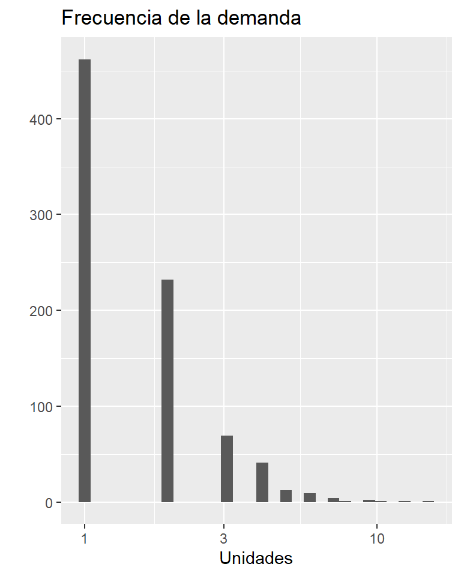

```r
par( mfrow = c(2,2) )

ggplot(dt1, aes(units)) + geom_histogram() + scale_x_log10() +ggtitle("Frecuencia de la demanda")+  labs(y="", x = "Unidades")
```

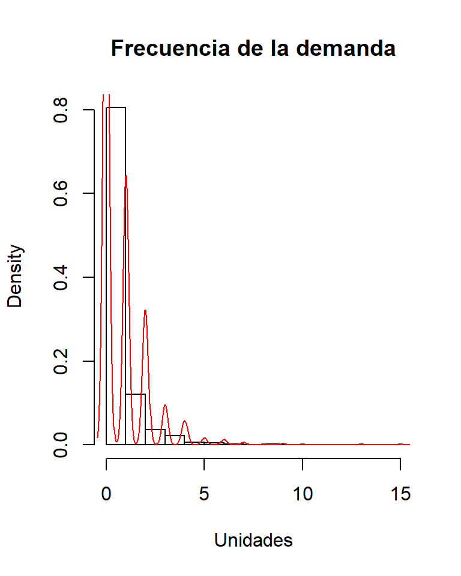

```r
par( mfrow = c(1,1))

z<-dt1$units

hist(z, freq = F ,main = "Frecuencia de la demanda", xlab = "Unidades")
lines(density(z), col="red")
```

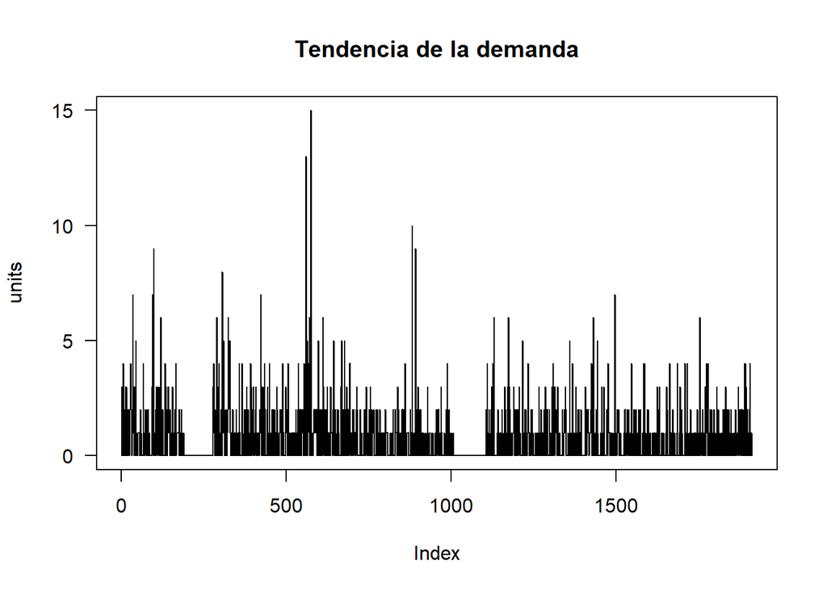

```r
with(dt1,
     plot(units, type="l",las=1, main = "Tendencia de la demanda"))
```

## Variable respuesta

```r
mean(dt1$units)
```

```
## [1] 0.7856769
```

```r
var(dt1$units)
```

```
## [1] 1.582703
```

## Selección de variables

Antes de ejecutar el modelo se necesitan quitar las variables que por conocimiento explicito no entran en el modelo

Serían:

- wm_yr_wk
- item_id
- d
- ln_units
- date

Son identificadores unicos y dañarían la interpretabilidad del modelo y no las recibe como atributos

```r
dt2<-dt1[,c(4,15:17,20:71)] # base lista para el modelo inicial

dt2$units<-as.numeric(dt2$units)
```

## Aplicación del modelo

```r
#summary(mod1<-zeroinfl(units~. |1,  dist = "poisson", link = "logit", data = dt2))
```

```r
#mnull <- update(mod1, . ~ 1)

#pchisq(2 * (logLik(mod1) - logLik(mnull)), df = 3, lower.tail = FALSE)
```

```r
summary(mod1 <- glm(units ~ ., family = poisson, data = dt2))
```

```
##
## Call:
## glm(formula = units ~ ., family = poisson, data = dt2)
##
## Deviance Residuals:
##     Min       1Q   Median       3Q      Max
## -1.8495  -1.2232  -0.9786   0.3961   7.3370
##
## Coefficients: (3 not defined because of singularities)
##                             Estimate Std. Error z value Pr(>|z|)
## (Intercept)                -0.126609   0.111383  -1.137 0.255664
## snap_CA                     0.086640   0.062467   1.387 0.165455
## snap_TX                    -0.053591   0.068340  -0.784 0.432928
## snap_WI                     0.043090   0.069061   0.624 0.532667
## weekday_Friday              0.241633   0.097937   2.467 0.013616 *
## weekday_Monday             -0.001388   0.105239  -0.013 0.989480
## weekday_Saturday            0.322899   0.096086   3.361 0.000778 ***
## weekday_Sunday              0.259914   0.099035   2.624 0.008679 **
## weekday_Thursday           -0.121236   0.106755  -1.136 0.256104
## weekday_Tuesday            -0.132541   0.106671  -1.243 0.214046
## weekday_Wednesday                 NA         NA      NA       NA
## month_2_enero              -0.614404   0.140565  -4.371 1.24e-05 ***
## month_2_febrero            -0.128459   0.121363  -1.058 0.289841
## month_2_marzo              -0.118584   0.115527  -1.026 0.304672
## month_2_abril              -0.176200   0.118978  -1.481 0.138621
## month_2_mayo                0.034625   0.117594   0.294 0.768419
## month_2_junio              -0.248385   0.127310  -1.951 0.051053 .
## month_2_julio              -0.258888   0.125350  -2.065 0.038893 *
## month_2_agosto             -0.217336   0.122805  -1.770 0.076766 .
## month_2_septiembre         -0.477242   0.134524  -3.548 0.000389 ***
## month_2_octubre            -0.540105   0.137441  -3.930 8.50e-05 ***
## month_2_noviembre          -0.274948   0.127245  -2.161 0.030713 *
## month_2_diciembre                 NA         NA      NA       NA
## events_superbowl           -1.174702   0.716673  -1.639 0.101192
## events_valentinesday        0.246603   0.394150   0.626 0.531539
## events_presidentday        -0.445174   0.590915  -0.753 0.451232
## events_lentstart           -0.189470   0.509160  -0.372 0.709802
## events_lentweek2           -0.155682   0.509487  -0.306 0.759935
## events_stpatricksday       -0.500559   0.583869  -0.857 0.391272
## events_purim_end            0.531860   0.343298   1.549 0.121317
```

[output cut: 21 more lines]

```
## events_martinluterkingday  -0.867038   1.009259  -0.859 0.390294
## events_easter               0.154195   0.418941   0.368 0.712830
## evento_manana               0.022027   0.093297   0.236 0.813355
## dumm_evento                       NA         NA      NA       NA
## evento_pasado_manana        0.015311   0.093204   0.164 0.869513
## ---
## Signif. codes:  0 '***' 0.001 '**' 0.01 '*' 0.05 '.' 0.1 ' ' 1
##
## (Dispersion parameter for poisson family taken to be 1)
##
##     Null deviance: 3079.8  on 1912  degrees of freedom
## Residual deviance: 2933.3  on 1860  degrees of freedom
## AIC: 5025.1
##
## Number of Fisher Scoring iterations: 12
```

# Intervalos de confianza para el modelo 1

```r
cov.m1 <- vcovHC(mod1, type="HC0")
std.err <- sqrt(diag(cov.m1))
r.est1 <- cbind(Estimate= coef(mod1), "Robust SE" = std.err,
"Pr(>|z|)" = 2 * pnorm(abs(coef(mod1)/std.err), lower.tail=FALSE),
LL = coef(mod1) - 1.96 * std.err,
UL = coef(mod1) + 1.96 * std.err)
r.est1
```

```
##                                Estimate  Robust SE      Pr(>|z|)            LL
## (Intercept)                -0.126608582 0.15900327  4.258786e-01  -0.438254991
## snap_CA                     0.086639567 0.08947260  3.328764e-01  -0.088726720
## snap_TX                    -0.053591326 0.09518362  5.734138e-01  -0.240151228
## snap_WI                     0.043090093 0.09137434  6.372283e-01  -0.136003620
## weekday_Friday              0.241633273 0.14319845  9.152617e-02  -0.039035681
## weekday_Monday             -0.001387597 0.15419026  9.928197e-01  -0.303600501
## weekday_Saturday            0.322899085 0.13220328  1.458820e-02   0.063780652
## weekday_Sunday              0.259913880 0.13474676  5.374249e-02  -0.004189766
## weekday_Thursday           -0.121236168 0.13834769  3.808588e-01  -0.392397644
## weekday_Tuesday            -0.132540539 0.13778291  3.360738e-01  -0.402595049
## weekday_Wednesday                    NA 0.18563881            NA            NA
## month_2_enero              -0.614403999 0.15583445  8.057913e-05  -0.919839530
## month_2_febrero            -0.128459191 0.15364189  4.031015e-01  -0.429597289
## month_2_marzo              -0.118584295 0.15504065  4.443553e-01  -0.422463973
## month_2_abril              -0.176200171 0.16099971  2.737739e-01  -0.491759593
## month_2_mayo                0.034624761 0.17579553  8.438585e-01  -0.309934477
## month_2_junio              -0.248385070 0.16668340  1.361820e-01  -0.575084532
## month_2_julio              -0.258887930 0.21996417  2.392135e-01  -0.690017706
## month_2_agosto             -0.217335787 0.18033425  2.281326e-01  -0.570790911
## month_2_septiembre         -0.477241763 0.18609304  1.033147e-02  -0.841984126
## month_2_octubre            -0.540105010 0.18779640  4.027323e-03  -0.908185951
## month_2_noviembre          -0.274947831 0.92333901  7.658744e-01  -2.084692283
## month_2_diciembre                    NA 0.29737879            NA            NA
## events_superbowl           -1.174702024 0.43962919  7.539409e-03  -2.036375228
## events_valentinesday        0.246603286 0.47510834  6.037284e-01  -0.684609064
## events_presidentday        -0.445173892 0.31402213  1.562926e-01  -1.060657267
## events_lentstart           -0.189469646 0.63878890  7.667661e-01  -1.441495888
## events_lentweek2           -0.155681758 0.71120748  8.267297e-01  -1.549648416
## events_stpatricksday       -0.500558552 0.57773736  3.862643e-01  -1.632923770
## events_purim_end            0.531860196 0.51707914  3.036744e-01  -0.481614917
## events_orthodoxeaster       0.187478710 0.78243907  8.106341e-01  -1.346101866
## events_pesach_end          -0.324931838 0.92440081  7.252093e-01  -2.136757417
## events_cinco_de_mayo       -1.405196011 0.47602228  3.157697e-03  -2.338199680
## events_mothers_day         -0.709469334 0.37853769  6.089777e-02  -1.451403215
## events_memorialday        -14.213570770 0.40362159 1.174925e-271 -15.004669093
## events_nbafinalstart       -0.117036520 0.34649233  7.355326e-01  -0.796161489
## events_nbafinalsend         0.800487951 0.60680621  1.871082e-01  -0.388852217
## events_fathers_day          0.808226953 0.55564824  1.457895e-01  -0.280843590
## events_independence_day    -0.719790212 0.49385719  1.449821e-01  -1.687750312
```

[output cut: 59 more lines]

```
## events_laborday             0.91356537
## events_columbusday          0.59443232
## events_haloween             1.19757976
## events_eidaladha            2.05881185
## events_veteransday          0.33455842
## events_thanksgiving         0.70581012
## events_christmas          -13.05426159
## events_chanukahend          1.88567215
## events_newyear              1.92085899
## events_orthodoxchristmas   -0.34605222
## events_martinluterkingday  -0.62205157
## events_easter               0.41374920
## evento_manana               0.33367379
## dumm_evento                         NA
## evento_pasado_manana        0.20187118
```

## Modelo 2

```r
mod2<-stepAIC(mod1, direction = "both", trace = FALSE)
summary(mod2)
```

```
##
## Call:
## glm(formula = units ~ snap_CA + weekday_Friday + weekday_Saturday +
##     weekday_Sunday + month_2_enero + month_2_febrero + month_2_marzo +
##     month_2_abril + month_2_junio + month_2_julio + month_2_agosto +
##     month_2_septiembre + month_2_octubre + month_2_noviembre +
##     events_superbowl + events_purim_end + events_cinco_de_mayo +
##     events_memorialday + events_nbafinalsend + events_fathers_day +
##     events_christmas, family = poisson, data = dt2)
##
## Deviance Residuals:
##     Min       1Q   Median       3Q      Max
## -1.8471  -1.2028  -0.9811   0.3879   7.3229
##
## Coefficients:
##                       Estimate Std. Error z value Pr(>|z|)
## (Intercept)           -0.18027    0.06649  -2.711  0.00671 **
## snap_CA                0.07989    0.05458   1.464  0.14322
## weekday_Friday         0.31672    0.07351   4.308 1.64e-05 ***
## weekday_Saturday       0.39642    0.07126   5.563 2.65e-08 ***
## weekday_Sunday         0.33178    0.07389   4.490 7.11e-06 ***
## month_2_enero         -0.65696    0.12402  -5.297 1.18e-07 ***
## month_2_febrero       -0.14428    0.10174  -1.418  0.15616
## month_2_marzo         -0.14353    0.09788  -1.466  0.14257
## month_2_abril         -0.18893    0.10092  -1.872  0.06118 .
## month_2_junio         -0.25941    0.11151  -2.326  0.02000 *
## month_2_julio         -0.28822    0.10900  -2.644  0.00819 **
## month_2_agosto        -0.22985    0.10646  -2.159  0.03085 *
## month_2_septiembre    -0.49949    0.11918  -4.191 2.78e-05 ***
## month_2_octubre       -0.55112    0.12019  -4.585 4.53e-06 ***
## month_2_noviembre     -0.30808    0.11074  -2.782  0.00540 **
## events_superbowl      -1.18573    0.71557  -1.657  0.09751 .
## events_purim_end       0.52692    0.34125   1.544  0.12257
## events_cinco_de_mayo  -1.40070    1.00249  -1.397  0.16235
## events_memorialday   -14.12231  346.04666  -0.041  0.96745
## events_nbafinalsend    0.76353    0.36779   2.076  0.03789 *
## events_fathers_day     0.80105    0.37170   2.155  0.03115 *
## events_christmas     -14.25508  344.35708  -0.041  0.96698
## ---
## Signif. codes:  0 '***' 0.001 '**' 0.01 '*' 0.05 '.' 0.1 ' ' 1
##
## (Dispersion parameter for poisson family taken to be 1)
##
##     Null deviance: 3079.8  on 1912  degrees of freedom
## Residual deviance: 2947.4  on 1891  degrees of freedom
## AIC: 4977.2
##
## Number of Fisher Scoring iterations: 12
```

## Intervalos de confianza para el modelo 2

```r
cov.m2 <- vcovHC(mod2, type="HC0")
std.err <- sqrt(diag(cov.m2))
r.est2 <- cbind(Estimate= coef(mod2), "Robust SE" = std.err,
"Pr(>|z|)" = 2 * pnorm(abs(coef(mod2)/std.err), lower.tail=FALSE),
LL = coef(mod2) - 1.96 * std.err,
UL = coef(mod2) + 1.96 * std.err)

r.est2
```

```
##                          Estimate  Robust SE      Pr(>|z|)           LL
## (Intercept)           -0.18027157 0.09047383  4.631324e-02  -0.35760027
## snap_CA                0.07989441 0.07769216  3.037872e-01  -0.07238222
## weekday_Friday         0.31672278 0.11276021  4.972391e-03   0.09571278
## weekday_Saturday       0.39642369 0.09730723  4.622465e-05   0.20570152
## weekday_Sunday         0.33177581 0.09994562  9.015835e-04   0.13588240
## month_2_enero         -0.65696444 0.16061106  4.306189e-05  -0.97176212
## month_2_febrero       -0.14428486 0.12434434  2.459001e-01  -0.38799976
## month_2_marzo         -0.14352741 0.12725211  2.593630e-01  -0.39294154
## month_2_abril         -0.18893467 0.12851720  1.415315e-01  -0.44082839
## month_2_junio         -0.25941165 0.15334288  9.070132e-02  -0.55996369
## month_2_julio         -0.28822064 0.14181907  4.212206e-02  -0.56618603
## month_2_agosto        -0.22984837 0.20231090  2.559086e-01  -0.62637773
## month_2_septiembre    -0.49949367 0.15863226  1.639692e-03  -0.81041290
## month_2_octubre       -0.55112403 0.15861001  5.114030e-04  -0.86199964
## month_2_noviembre     -0.30807521 0.16536337  6.245950e-02  -0.63218740
## events_superbowl      -1.18572608 0.92242627  1.986376e-01  -2.99368156
## events_purim_end       0.52692048 0.70646707  4.557563e-01  -0.85775497
## events_cinco_de_mayo  -1.40069550 0.77817266  7.186374e-02  -2.92591392
## events_memorialday   -14.12231352 0.45627351 2.431189e-210 -15.01660960
## events_nbafinalsend    0.76353133 0.40710386  6.072126e-02  -0.03439224
## events_fathers_day     0.80105458 0.34336623  1.965102e-02   0.12805678
## events_christmas     -14.25507608 0.46105548 6.769345e-210 -15.15874482
##                                 UL
## (Intercept)           -0.002942864
## snap_CA                0.232171038
## weekday_Friday         0.537732788
## weekday_Saturday       0.587145858
## weekday_Sunday         0.527669228
## month_2_enero         -0.342166756
## month_2_febrero        0.099430040
## month_2_marzo          0.105886723
## month_2_abril          0.062959052
## month_2_junio          0.041140392
## month_2_julio         -0.010255252
## month_2_agosto         0.166680998
## month_2_septiembre    -0.188574444
## month_2_octubre       -0.240248409
## month_2_noviembre      0.016036989
## events_superbowl       0.622229401
## events_purim_end       1.911595934
## events_cinco_de_mayo   0.124522911
## events_memorialday   -13.228017449
## events_nbafinalsend    1.561454897
## events_fathers_day     1.474052386
## events_christmas     -13.351407345
```

## Comparación de modelos

```r
anova(mod2, mod1, test="Chisq")
```

```
## Analysis of Deviance Table
##
## Model 1: units ~ snap_CA + weekday_Friday + weekday_Saturday + weekday_Sunday +
##     month_2_enero + month_2_febrero + month_2_marzo + month_2_abril +
##     month_2_junio + month_2_julio + month_2_agosto + month_2_septiembre +
##     month_2_octubre + month_2_noviembre + events_superbowl +
##     events_purim_end + events_cinco_de_mayo + events_memorialday +
##     events_nbafinalsend + events_fathers_day + events_christmas
## Model 2: units ~ snap_CA + snap_TX + snap_WI + weekday_Friday + weekday_Monday +
##     weekday_Saturday + weekday_Sunday + weekday_Thursday + weekday_Tuesday +
##     weekday_Wednesday + month_2_enero + month_2_febrero + month_2_marzo +
##     month_2_abril + month_2_mayo + month_2_junio + month_2_julio +
##     month_2_agosto + month_2_septiembre + month_2_octubre + month_2_noviembre +
##     month_2_diciembre + events_superbowl + events_valentinesday +
##     events_presidentday + events_lentstart + events_lentweek2 +
##     events_stpatricksday + events_purim_end + events_orthodoxeaster +
##     events_pesach_end + events_cinco_de_mayo + events_mothers_day +
##     events_memorialday + events_nbafinalstart + events_nbafinalsend +
##     events_fathers_day + events_independence_day + events_radaman_starts +
##     events_eid_alfitr + events_laborday + events_columbusday +
##     events_haloween + events_eidaladha + events_veteransday +
##     events_thanksgiving + events_christmas + events_chanukahend +
##     events_newyear + events_orthodoxchristmas + events_martinluterkingday +
##     events_easter + evento_manana + dumm_evento + evento_pasado_manana
##   Resid. Df Resid. Dev Df Deviance Pr(>Chi)
## 1      1891     2947.4
## 2      1860     2933.3 31   14.054   0.9961
```

## Modelo 3

```r
mod3<-stepAIC(mod2, direction = "both", trace = FALSE)
summary(mod3)
```

```
##
## Call:
## glm(formula = units ~ snap_CA + weekday_Friday + weekday_Saturday +
##     weekday_Sunday + month_2_enero + month_2_febrero + month_2_marzo +
##     month_2_abril + month_2_junio + month_2_julio + month_2_agosto +
##     month_2_septiembre + month_2_octubre + month_2_noviembre +
##     events_superbowl + events_purim_end + events_cinco_de_mayo +
##     events_memorialday + events_nbafinalsend + events_fathers_day +
##     events_christmas, family = poisson, data = dt2)
##
## Deviance Residuals:
##     Min       1Q   Median       3Q      Max
## -1.8471  -1.2028  -0.9811   0.3879   7.3229
##
## Coefficients:
##                       Estimate Std. Error z value Pr(>|z|)
## (Intercept)           -0.18027    0.06649  -2.711  0.00671 **
## snap_CA                0.07989    0.05458   1.464  0.14322
## weekday_Friday         0.31672    0.07351   4.308 1.64e-05 ***
## weekday_Saturday       0.39642    0.07126   5.563 2.65e-08 ***
## weekday_Sunday         0.33178    0.07389   4.490 7.11e-06 ***
## month_2_enero         -0.65696    0.12402  -5.297 1.18e-07 ***
## month_2_febrero       -0.14428    0.10174  -1.418  0.15616
## month_2_marzo         -0.14353    0.09788  -1.466  0.14257
## month_2_abril         -0.18893    0.10092  -1.872  0.06118 .
## month_2_junio         -0.25941    0.11151  -2.326  0.02000 *
## month_2_julio         -0.28822    0.10900  -2.644  0.00819 **
## month_2_agosto        -0.22985    0.10646  -2.159  0.03085 *
## month_2_septiembre    -0.49949    0.11918  -4.191 2.78e-05 ***
## month_2_octubre       -0.55112    0.12019  -4.585 4.53e-06 ***
## month_2_noviembre     -0.30808    0.11074  -2.782  0.00540 **
## events_superbowl      -1.18573    0.71557  -1.657  0.09751 .
## events_purim_end       0.52692    0.34125   1.544  0.12257
## events_cinco_de_mayo  -1.40070    1.00249  -1.397  0.16235
## events_memorialday   -14.12231  346.04666  -0.041  0.96745
## events_nbafinalsend    0.76353    0.36779   2.076  0.03789 *
## events_fathers_day     0.80105    0.37170   2.155  0.03115 *
## events_christmas     -14.25508  344.35708  -0.041  0.96698
## ---
## Signif. codes:  0 '***' 0.001 '**' 0.01 '*' 0.05 '.' 0.1 ' ' 1
##
## (Dispersion parameter for poisson family taken to be 1)
##
##     Null deviance: 3079.8  on 1912  degrees of freedom
## Residual deviance: 2947.4  on 1891  degrees of freedom
## AIC: 4977.2
##
## Number of Fisher Scoring iterations: 12
```

## Intervalos de confianza para el modelo 3

```r
cov.m3 <- vcovHC(mod3, type="HC0")
std.err <- sqrt(diag(cov.m3))
r.est3 <- cbind(Estimate= coef(mod3), "Robust SE" = std.err,
"Pr(>|z|)" = 2 * pnorm(abs(coef(mod3)/std.err), lower.tail=FALSE),
LL = coef(mod3) - 1.96 * std.err,
UL = coef(mod3) + 1.96 * std.err)

r.est3
```

```
##                          Estimate  Robust SE      Pr(>|z|)           LL
## (Intercept)           -0.18027157 0.09047383  4.631324e-02  -0.35760027
## snap_CA                0.07989441 0.07769216  3.037872e-01  -0.07238222
## weekday_Friday         0.31672278 0.11276021  4.972391e-03   0.09571278
## weekday_Saturday       0.39642369 0.09730723  4.622465e-05   0.20570152
## weekday_Sunday         0.33177581 0.09994562  9.015835e-04   0.13588240
## month_2_enero         -0.65696444 0.16061106  4.306189e-05  -0.97176212
## month_2_febrero       -0.14428486 0.12434434  2.459001e-01  -0.38799976
## month_2_marzo         -0.14352741 0.12725211  2.593630e-01  -0.39294154
## month_2_abril         -0.18893467 0.12851720  1.415315e-01  -0.44082839
## month_2_junio         -0.25941165 0.15334288  9.070132e-02  -0.55996369
## month_2_julio         -0.28822064 0.14181907  4.212206e-02  -0.56618603
## month_2_agosto        -0.22984837 0.20231090  2.559086e-01  -0.62637773
## month_2_septiembre    -0.49949367 0.15863226  1.639692e-03  -0.81041290
## month_2_octubre       -0.55112403 0.15861001  5.114030e-04  -0.86199964
## month_2_noviembre     -0.30807521 0.16536337  6.245950e-02  -0.63218740
## events_superbowl      -1.18572608 0.92242627  1.986376e-01  -2.99368156
## events_purim_end       0.52692048 0.70646707  4.557563e-01  -0.85775497
## events_cinco_de_mayo  -1.40069550 0.77817266  7.186374e-02  -2.92591392
## events_memorialday   -14.12231352 0.45627351 2.431189e-210 -15.01660960
## events_nbafinalsend    0.76353133 0.40710386  6.072126e-02  -0.03439224
## events_fathers_day     0.80105458 0.34336623  1.965102e-02   0.12805678
## events_christmas     -14.25507608 0.46105548 6.769345e-210 -15.15874482
##                                 UL
## (Intercept)           -0.002942864
## snap_CA                0.232171038
## weekday_Friday         0.537732788
## weekday_Saturday       0.587145858
## weekday_Sunday         0.527669228
## month_2_enero         -0.342166756
## month_2_febrero        0.099430040
## month_2_marzo          0.105886723
## month_2_abril          0.062959052
## month_2_junio          0.041140392
## month_2_julio         -0.010255252
## month_2_agosto         0.166680998
## month_2_septiembre    -0.188574444
## month_2_octubre       -0.240248409
## month_2_noviembre      0.016036989
## events_superbowl       0.622229401
## events_purim_end       1.911595934
## events_cinco_de_mayo   0.124522911
## events_memorialday   -13.228017449
## events_nbafinalsend    1.561454897
## events_fathers_day     1.474052386
## events_christmas     -13.351407345
```

## Comparación de los 3 modelos

```r
anova(mod3, mod2, mod1, test="Chisq")
```

```
## Analysis of Deviance Table
##
## Model 1: units ~ snap_CA + weekday_Friday + weekday_Saturday + weekday_Sunday +
##     month_2_enero + month_2_febrero + month_2_marzo + month_2_abril +
##     month_2_junio + month_2_julio + month_2_agosto + month_2_septiembre +
##     month_2_octubre + month_2_noviembre + events_superbowl +
##     events_purim_end + events_cinco_de_mayo + events_memorialday +
##     events_nbafinalsend + events_fathers_day + events_christmas
## Model 2: units ~ snap_CA + weekday_Friday + weekday_Saturday + weekday_Sunday +
##     month_2_enero + month_2_febrero + month_2_marzo + month_2_abril +
##     month_2_junio + month_2_julio + month_2_agosto + month_2_septiembre +
##     month_2_octubre + month_2_noviembre + events_superbowl +
##     events_purim_end + events_cinco_de_mayo + events_memorialday +
##     events_nbafinalsend + events_fathers_day + events_christmas
## Model 3: units ~ snap_CA + snap_TX + snap_WI + weekday_Friday + weekday_Monday +
##     weekday_Saturday + weekday_Sunday + weekday_Thursday + weekday_Tuesday +
##     weekday_Wednesday + month_2_enero + month_2_febrero + month_2_marzo +
##     month_2_abril + month_2_mayo + month_2_junio + month_2_julio +
##     month_2_agosto + month_2_septiembre + month_2_octubre + month_2_noviembre +
##     month_2_diciembre + events_superbowl + events_valentinesday +
##     events_presidentday + events_lentstart + events_lentweek2 +
##     events_stpatricksday + events_purim_end + events_orthodoxeaster +
##     events_pesach_end + events_cinco_de_mayo + events_mothers_day +
##     events_memorialday + events_nbafinalstart + events_nbafinalsend +
##     events_fathers_day + events_independence_day + events_radaman_starts +
##     events_eid_alfitr + events_laborday + events_columbusday +
##     events_haloween + events_eidaladha + events_veteransday +
##     events_thanksgiving + events_christmas + events_chanukahend +
##     events_newyear + events_orthodoxchristmas + events_martinluterkingday +
##     events_easter + evento_manana + dumm_evento + evento_pasado_manana
##   Resid. Df Resid. Dev Df Deviance Pr(>Chi)
## 1      1891     2947.4
## 2      1891     2947.4  0    0.000
## 3      1860     2933.3 31   14.054   0.9961
```

## Comparación entre los coeficientes entre los modelos

```r
#extrae los coeficientes de cada modelo

coef1<-coef(mod1)

coef2<-coef(mod2)

coef3<-coef(mod3)


# extraer el error estandar de cada modelo

se.coef1<-se.coef(mod1)
se.coef2<-se.coef(mod2)
se.coef3<-se.coef(mod3)

# uniendo los resultados

modelos<-cbind(coef1,coef2, coef3, se.coef1, se.coef2, se.coef3)
# resultados



modelos  %>%
  kable() %>%
  kable_styling() %>%
  kableExtra::scroll_box(width = "100%")
```

|  | coef1 | coef2 | coef3 | se.coef1 | se.coef2 | se.coef3 |
| --- | --- | --- | --- | --- | --- | --- |
| (Intercept) | -0.1266086 | -0.1802716 | -0.1802716 | 0.1113827 | 0.0664929 | 0.0664929 |
| snap_CA | 0.0866396 | 0.0798944 | 0.0798944 | 0.0624674 | 0.0545766 | 0.0545766 |
| snap_TX | -0.0535913 | 0.3167228 | 0.3167228 | 0.0683396 | 0.0735138 | 0.0735138 |
| snap_WI | 0.0430901 | 0.3964237 | 0.3964237 | 0.0690612 | 0.0712620 | 0.0712620 |
| weekday_Friday | 0.2416333 | 0.3317758 | 0.3317758 | 0.0979369 | 0.0738874 | 0.0738874 |
| weekday_Monday | -0.0013876 | -0.6569644 | -0.6569644 | 0.1052388 | 0.1240228 | 0.1240228 |
| weekday_Saturday | 0.3228991 | -0.1442849 | -0.1442849 | 0.0960864 | 0.1017447 | 0.1017447 |
| weekday_Sunday | 0.2599139 | -0.1435274 | -0.1435274 | 0.0990351 | 0.0978842 | 0.0978842 |
| weekday_Thursday | -0.1212362 | -0.1889347 | -0.1889347 | 0.1067550 | 0.1009166 | 0.1009166 |
| weekday_Tuesday | -0.1325405 | -0.2594116 | -0.2594116 | 0.1066710 | 0.1115081 | 0.1115081 |
| weekday_Wednesday | NA | -0.2882206 | -0.2882206 | NA | 0.1090015 | 0.1090015 |
| month_2_enero | -0.6144040 | -0.2298484 | -0.2298484 | 0.1405653 | 0.1064592 | 0.1064592 |
| month_2_febrero | -0.1284592 | -0.4994937 | -0.4994937 | 0.1213630 | 0.1191784 | 0.1191784 |
| month_2_marzo | -0.1185843 | -0.5511240 | -0.5511240 | 0.1155268 | 0.1201892 | 0.1201892 |
| month_2_abril | -0.1762002 | -0.3080752 | -0.3080752 | 0.1189780 | 0.1107361 | 0.1107361 |
| month_2_mayo | 0.0346248 | -1.1857261 | -1.1857261 | 0.1175938 | 0.7155724 | 0.7155724 |
| month_2_junio | -0.2483851 | 0.5269205 | 0.5269205 | 0.1273095 | 0.3412507 | 0.3412507 |
| month_2_julio | -0.2588879 | -1.4006955 | -1.4006955 | 0.1253504 | 1.0024922 | 1.0024922 |
| month_2_agosto | -0.2173358 | -14.1223135 | -14.1223135 | 0.1228047 | 346.0466556 | 346.0466556 |
| month_2_septiembre | -0.4772418 | 0.7635313 | 0.7635313 | 0.1345242 | 0.3677876 | 0.3677876 |
| month_2_octubre | -0.5401050 | 0.8010546 | 0.8010546 | 0.1374415 | 0.3716952 | 0.3716952 |
| month_2_noviembre | -0.2749478 | -14.2550761 | -14.2550761 | 0.1272455 | 344.3570753 | 344.3570753 |
| month_2_diciembre | NA | -0.1802716 | -0.1802716 | NA | 0.0664929 | 0.0664929 |
| events_superbowl | -1.1747020 | 0.0798944 | 0.0798944 | 0.7166731 | 0.0545766 | 0.0545766 |
| events_valentinesday | 0.2466033 | 0.3167228 | 0.3167228 | 0.3941503 | 0.0735138 | 0.0735138 |
| events_presidentday | -0.4451739 | 0.3964237 | 0.3964237 | 0.5909154 | 0.0712620 | 0.0712620 |
| events_lentstart | -0.1894696 | 0.3317758 | 0.3317758 | 0.5091598 | 0.0738874 | 0.0738874 |
| events_lentweek2 | -0.1556818 | -0.6569644 | -0.6569644 | 0.5094868 | 0.1240228 | 0.1240228 |
| events_stpatricksday | -0.5005586 | -0.1442849 | -0.1442849 | 0.5838689 | 0.1017447 | 0.1017447 |
| events_purim_end | 0.5318602 | -0.1435274 | -0.1435274 | 0.3432979 | 0.0978842 | 0.0978842 |
| events_orthodoxeaster | 0.1874787 | -0.1889347 | -0.1889347 | 0.4576972 | 0.1009166 | 0.1009166 |
| events_pesach_end | -0.3249318 | -0.2594116 | -0.2594116 | 0.5874677 | 0.1115081 | 0.1115081 |
| events_cinco_de_mayo | -1.4051960 | -0.2882206 | -0.2882206 | 1.0050680 | 0.1090015 | 0.1090015 |
| events_mothers_day | -0.7094693 | -0.2298484 | -0.2298484 | 0.5872617 | 0.1064592 | 0.1064592 |
| events_memorialday | -14.2135708 | -0.4994937 | -0.4994937 | 346.0315513 | 0.1191784 | 0.1191784 |
| events_nbafinalstart | -0.1170365 | -0.5511240 | -0.5511240 | 0.5848515 | 0.1201892 | 0.1201892 |
| events_nbafinalsend | 0.8004880 | -0.3080752 | -0.3080752 | 0.3698657 | 0.1107361 | 0.1107361 |
| events_fathers_day | 0.8082270 | -1.1857261 | -1.1857261 | 0.3728666 | 0.7155724 | 0.7155724 |
| events_independence_day | -0.7197902 | 0.5269205 | 0.5269205 | 0.7159600 | 0.3412507 | 0.3412507 |
| events_radaman_starts | 0.0670185 | -1.4006955 | -1.4006955 | 0.5038598 | 1.0024922 | 1.0024922 |
| events_eid_alfitr | 0.0308723 | -14.1223135 | -14.1223135 | 0.5050478 | 346.0466556 | 346.0466556 |
| events_laborday | -0.3813146 | 0.7635313 | 0.7635313 | 0.7196503 | 0.3677876 | 0.3677876 |
| events_columbusday | -0.2938666 | 0.8010546 | 0.8010546 | 0.7195813 | 0.3716952 | 0.3716952 |
| events_haloween | 0.0535315 | -14.2550761 | -14.2550761 | 0.5884866 | 344.3570753 | 344.3570753 |
| events_eidaladha | 0.2721349 | -0.1802716 | -0.1802716 | 0.5061046 | 0.0664929 | 0.0664929 |
| events_veteransday | -0.5894243 | 0.0798944 | 0.0798944 | 0.7166786 | 0.0545766 | 0.0545766 |
| events_thanksgiving | -0.3934981 | 0.3167228 | 0.3167228 | 0.7179311 | 0.0735138 | 0.0735138 |
| events_christmas | -14.2265984 | 0.3964237 | 0.3964237 | 343.6953090 | 0.0712620 | 0.0712620 |
| events_chanukahend | 0.2473500 | 0.3317758 | 0.3317758 | 0.4179667 | 0.0738874 | 0.0738874 |
| events_newyear | 0.1328807 | -0.6569644 | -0.6569644 | 0.5935391 | 0.1240228 | 0.1240228 |
| events_orthodoxchristmas | -0.9293672 | -0.1442849 | -0.1442849 | 1.0095410 | 0.1017447 | 0.1017447 |
| events_martinluterkingday | -0.8670377 | -0.1435274 | -0.1435274 | 1.0092587 | 0.0978842 | 0.0978842 |
| events_easter | 0.1541949 | -0.1889347 | -0.1889347 | 0.4189415 | 0.1009166 | 0.1009166 |
| evento_manana | 0.0220274 | -0.2594116 | -0.2594116 | 0.0932970 | 0.1115081 | 0.1115081 |
| dumm_evento | NA | -0.2882206 | -0.2882206 | NA | 0.1090015 | 0.1090015 |
| evento_pasado_manana | 0.0153113 | -0.2298484 | -0.2298484 | 0.0932040 | 0.1064592 | 0.1064592 |

## Modelo 4

```r
mod4<-stepAIC(mod3, direction = "both", trace = FALSE)
summary(mod4)
```

```
##
## Call:
## glm(formula = units ~ snap_CA + weekday_Friday + weekday_Saturday +
##     weekday_Sunday + month_2_enero + month_2_febrero + month_2_marzo +
##     month_2_abril + month_2_junio + month_2_julio + month_2_agosto +
##     month_2_septiembre + month_2_octubre + month_2_noviembre +
##     events_superbowl + events_purim_end + events_cinco_de_mayo +
##     events_memorialday + events_nbafinalsend + events_fathers_day +
##     events_christmas, family = poisson, data = dt2)
##
## Deviance Residuals:
##     Min       1Q   Median       3Q      Max
## -1.8471  -1.2028  -0.9811   0.3879   7.3229
##
## Coefficients:
##                       Estimate Std. Error z value Pr(>|z|)
## (Intercept)           -0.18027    0.06649  -2.711  0.00671 **
## snap_CA                0.07989    0.05458   1.464  0.14322
## weekday_Friday         0.31672    0.07351   4.308 1.64e-05 ***
## weekday_Saturday       0.39642    0.07126   5.563 2.65e-08 ***
## weekday_Sunday         0.33178    0.07389   4.490 7.11e-06 ***
## month_2_enero         -0.65696    0.12402  -5.297 1.18e-07 ***
## month_2_febrero       -0.14428    0.10174  -1.418  0.15616
## month_2_marzo         -0.14353    0.09788  -1.466  0.14257
## month_2_abril         -0.18893    0.10092  -1.872  0.06118 .
## month_2_junio         -0.25941    0.11151  -2.326  0.02000 *
## month_2_julio         -0.28822    0.10900  -2.644  0.00819 **
## month_2_agosto        -0.22985    0.10646  -2.159  0.03085 *
## month_2_septiembre    -0.49949    0.11918  -4.191 2.78e-05 ***
## month_2_octubre       -0.55112    0.12019  -4.585 4.53e-06 ***
## month_2_noviembre     -0.30808    0.11074  -2.782  0.00540 **
## events_superbowl      -1.18573    0.71557  -1.657  0.09751 .
## events_purim_end       0.52692    0.34125   1.544  0.12257
## events_cinco_de_mayo  -1.40070    1.00249  -1.397  0.16235
## events_memorialday   -14.12231  346.04666  -0.041  0.96745
## events_nbafinalsend    0.76353    0.36779   2.076  0.03789 *
## events_fathers_day     0.80105    0.37170   2.155  0.03115 *
## events_christmas     -14.25508  344.35708  -0.041  0.96698
## ---
## Signif. codes:  0 '***' 0.001 '**' 0.01 '*' 0.05 '.' 0.1 ' ' 1
##
## (Dispersion parameter for poisson family taken to be 1)
##
##     Null deviance: 3079.8  on 1912  degrees of freedom
## Residual deviance: 2947.4  on 1891  degrees of freedom
## AIC: 4977.2
##
## Number of Fisher Scoring iterations: 12
```

## Gráficas de los modelos

#### Modelo 1

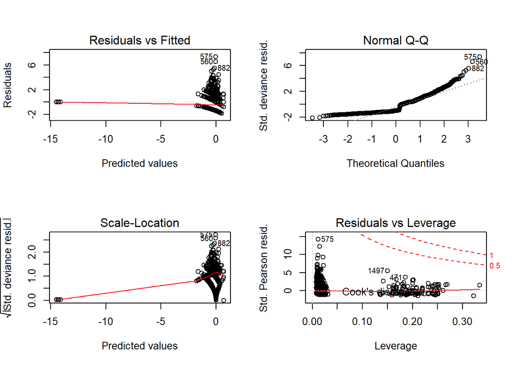

```r
par( mfrow = c(2,2) )

plot(mod1) # modelo 1
```

#### Modelo 2

```r
par( mfrow = c(2,2) )

plot(mod2) # modelo 1
```

[output not shown]

#### Modelo 3

```r
par( mfrow = c(2,2) )

plot(mod3) # modelo 1
```

[output not shown]

#### Modelo 4

```r
par( mfrow = c(2,2) )

plot(mod4) # modelo 1
```

[output not shown]

# Evaluando los modelos

## Modelo 1

```r
Predict_demand<-as.data.frame(predict(mod1,dt2))
colnames(Predict_demand)[1]<-"NewDemand"
#Predict_demand

Date<-as.data.frame(dt1$date)
oldDemand<-as.data.frame(dt1$units)


newdata<-as.data.frame(cbind(Date,Predict_demand,oldDemand))
colnames(newdata)[1]<-"Date"
colnames(newdata)[2]<-"NewDemand"
colnames(newdata)[3]<-"oldDemand"
```

## Modelo 2

```r
Predict_demand2<-as.data.frame(predict(mod2,dt2))
colnames(Predict_demand2)[1]<-"NewDemand"
#Predict_demand

Date2<-as.data.frame(dt1$date)
oldDemand<-as.data.frame(dt1$units)


newdata2<-as.data.frame(cbind(Date2,Predict_demand2,oldDemand))
colnames(newdata2)[1]<-"Date"
colnames(newdata2)[2]<-"NewDemand"
colnames(newdata2)[3]<-"oldDemand"
```

## Modelo 3

```r
Predict_demand3<-as.data.frame(predict(mod3,dt2))
colnames(Predict_demand3)[1]<-"NewDemand"
#Predict_demand

Date3<-as.data.frame(dt1$date)
oldDemand<-as.data.frame(dt1$units)


newdata3<-as.data.frame(cbind(Date3,Predict_demand3,oldDemand))
colnames(newdata3)[1]<-"Date"
colnames(newdata3)[2]<-"NewDemand"
colnames(newdata3)[3]<-"oldDemand"
```

## Modelo 4

```r
Predict_demand4<-as.data.frame(predict(mod4,dt2))
colnames(Predict_demand4)[1]<-"NewDemand"
#Predict_demand

Date4<-as.data.frame(dt1$date)
oldDemand<-as.data.frame(dt1$units)


newdata4<-as.data.frame(cbind(Date4,Predict_demand4,oldDemand))
colnames(newdata4)[1]<-"Date"
colnames(newdata4)[2]<-"NewDemand"
colnames(newdata4)[3]<-"oldDemand"
```

# Métrica MASE

Modelo 1

```r
mase(newdata$oldDemand,newdata$NewDemand,1)
```

```
## [1] 1.126938
```

```r
mase(newdata2$oldDemand,newdata$NewDemand,1)
```

```
## [1] 1.126938
```

```r
mase(newdata3$oldDemand,newdata$NewDemand,1)
```

```
## [1] 1.126938
```

```r
mase(newdata4$oldDemand,newdata$NewDemand,1)
```

```
## [1] 1.126938
```